# ANCOVA in Triagem Test - Reading of Words per Minutes and Reading Comprehension (Teste Triagem - Leitura de Palavras por Minuto e Compreensao Leitora)

Geiser C. Challco geiser@alumni.usp.br

- Descriptive Statistics of Initial Data
  - Quant. Palavras Lidas
  - Compreensao Leitora (Acertos)
- Checking of Assumptions
  - Assumption: Normality distribution
    - Quant. Palavras Lidas
    - Compreensao Leitora (Acertos)
  - Assumption: Homogeneity
    - Quant. Palavras Lidas
    - Compreensao Leitora (Acertos)
- Computation of ANCOVA test and Pairwise Comparison
  - ANCOVA tests for one factor
    - Quant. Palavras Lidas
    - Compreensao Leitora (Acertos)
  - ANCOVA tests for two factors
    - Quant. Palavras Lidas
    - Compreensao Leitora (Acertos)
  - ANCOVA tests for grupo=“Experimental”
    - Quant. Palavras Lidas
    - Compreensao Leitora (Acertos)
- Pairwise comparisons for one factor
  - factor: **grupo**
    - Quant. Palavras Lidas
    - Compreensao Leitora (Acertos)
  - factor: **genero**
    - Quant. Palavras Lidas
    - Compreensao Leitora (Acertos)
  - factor: **idade**
    - Quant. Palavras Lidas
    - Compreensao Leitora (Acertos)
  - factor: **zona.participante**
    - Quant. Palavras Lidas
    - Compreensao Leitora (Acertos)
  - factor: **escola**
    - Quant. Palavras Lidas
    - Compreensao Leitora (Acertos)
  - factor: **zona.escola**
    - Quant. Palavras Lidas
    - Compreensao Leitora (Acertos)
- Pairwise comparisons for two factors
  - factores: **genero:grupo**
    - Quant. Palavras Lidas
    - Compreensao Leitora (Acertos)
  - factores: **idade:grupo**
    - Quant. Palavras Lidas
    - Compreensao Leitora (Acertos)
  - factores: **zona.participante:grupo**
    - Quant. Palavras Lidas
    - Compreensao Leitora (Acertos)
  - factores: **escola:grupo**
    - Quant. Palavras Lidas
    - Compreensao Leitora (Acertos)
  - factores: **zona.escola:grupo**
    - Quant. Palavras Lidas
    - Compreensao Leitora (Acertos)
- Pairwise comparisons for grupo=“Experimental”
  - factores: **grupo=“Experimental”:monitor**
    - Quant. Palavras Lidas
    - Compreensao Leitora (Acertos)
  - factores: **grupo=“Experimental”:monitor.genero**
    - Quant. Palavras Lidas
    - Compreensao Leitora (Acertos)
  - factores: **grupo=“Experimental”:monitor.area**
    - Quant. Palavras Lidas
    - Compreensao Leitora (Acertos)
  - factores: **grupo=“Experimental”:monitor.formacao**
    - Quant. Palavras Lidas
    - Compreensao Leitora (Acertos)
  - factores: **grupo=“Experimental”:monitor.experiencia**
    - Quant. Palavras Lidas
    - Compreensao Leitora (Acertos)

**NOTE**

- Teste ANCOVA para determinar se houve diferenças significativas no Teste Triagem - Leitura de Palavras por Minuto e Compreensao Leitora (medido usando pre- e pos-testes).
- ANCOVA test to determine whether there were significant differences in Triagem Test - Reading of Words per Minutes and Reading Comprehension (measured using pre- and post-tests).

# Descriptive Statistics of Initial Data

## Quant. Palavras Lidas

| grupo | genero | idade | zona.participante | escola | zona.escola | variable | n | mean | median | min | max | sd | se | ci | iqr |
| --- | --- | --- | --- | --- | --- | --- | --- | --- | --- | --- | --- | --- | --- | --- | --- |
| Controle | F |  |  |  |  | palavras.lidas.pos | 7 | 87.000 | 87.0 | 43 | 162 | 38.884 | 14.697 | 35.962 | 25.50 |
| Controle | M |  |  |  |  | palavras.lidas.pos | 9 | 103.333 | 70.0 | 29 | 363 | 104.490 | 34.830 | 80.318 | 42.00 |
| stari+WG | F |  |  |  |  | palavras.lidas.pos | 2 | 91.000 | 91.0 | 79 | 103 | 16.971 | 12.000 | 152.474 | 12.00 |
| stari+WG | M |  |  |  |  | palavras.lidas.pos | 14 | 93.143 | 82.5 | 37 | 162 | 38.145 | 10.195 | 22.024 | 37.75 |
| Controle | F |  |  |  |  | palavras.lidas.pre | 7 | 52.000 | 42.0 | 29 | 101 | 25.554 | 9.658 | 23.633 | 28.00 |
| Controle | M |  |  |  |  | palavras.lidas.pre | 9 | 87.444 | 70.0 | 33 | 228 | 62.915 | 20.972 | 48.361 | 32.00 |
| stari+WG | F |  |  |  |  | palavras.lidas.pre | 2 | 89.000 | 89.0 | 44 | 134 | 63.640 | 45.000 | 571.779 | 45.00 |
| stari+WG | M |  |  |  |  | palavras.lidas.pre | 14 | 134.857 | 142.5 | 7 | 299 | 95.914 | 25.634 | 55.379 | 118.75 |
| Controle |  | 10y |  |  |  | palavras.lidas.pos | 4 | 77.750 | 87.0 | 43 | 94 | 23.528 | 11.764 | 37.439 | 17.25 |
| Controle |  | 11y |  |  |  | palavras.lidas.pos | 9 | 114.111 | 70.0 | 40 | 363 | 104.183 | 34.728 | 80.082 | 110.00 |
| Controle |  | 12y |  |  |  | palavras.lidas.pos | 1 | 85.000 | 85.0 | 85 | 85 |  |  |  | 0.00 |
| Controle |  | 13y |  |  |  | palavras.lidas.pos | 1 | 87.000 | 87.0 | 87 | 87 |  |  |  | 0.00 |
| Controle |  | 15y |  |  |  | palavras.lidas.pos | 1 | 29.000 | 29.0 | 29 | 29 |  |  |  | 0.00 |
| stari+WG |  | 10y |  |  |  | palavras.lidas.pos | 4 | 110.750 | 109.0 | 68 | 157 | 48.355 | 24.178 | 76.944 | 80.75 |
| stari+WG |  | 11y |  |  |  | palavras.lidas.pos | 9 | 88.333 | 84.0 | 37 | 162 | 35.770 | 11.923 | 27.495 | 39.00 |
| stari+WG |  | 12y |  |  |  | palavras.lidas.pos | 1 | 74.000 | 74.0 | 74 | 74 |  |  |  | 0.00 |
| stari+WG |  | 13y |  |  |  | palavras.lidas.pos | 2 | 87.000 | 87.0 | 81 | 93 | 8.485 | 6.000 | 76.237 | 6.00 |
| Controle |  | 10y |  |  |  | palavras.lidas.pre | 4 | 49.500 | 50.0 | 32 | 66 | 15.351 | 7.676 | 24.428 | 20.50 |
| Controle |  | 11y |  |  |  | palavras.lidas.pre | 9 | 60.556 | 69.0 | 33 | 101 | 22.897 | 7.632 | 17.600 | 30.00 |
| Controle |  | 12y |  |  |  | palavras.lidas.pre | 1 | 228.000 | 228.0 | 228 | 228 |  |  |  | 0.00 |
| Controle |  | 13y |  |  |  | palavras.lidas.pre | 1 | 29.000 | 29.0 | 29 | 29 |  |  |  | 0.00 |
| Controle |  | 15y |  |  |  | palavras.lidas.pre | 1 | 151.000 | 151.0 | 151 | 151 |  |  |  | 0.00 |
| stari+WG |  | 10y |  |  |  | palavras.lidas.pre | 4 | 157.500 | 139.0 | 62 | 290 | 113.890 | 56.945 | 181.225 | 171.00 |
| stari+WG |  | 11y |  |  |  | palavras.lidas.pre | 9 | 135.778 | 134.0 | 7 | 299 | 85.704 | 28.568 | 65.878 | 90.00 |
| stari+WG |  | 12y |  |  |  | palavras.lidas.pre | 1 | 30.000 | 30.0 | 30 | 30 |  |  |  | 0.00 |
| stari+WG |  | 13y |  |  |  | palavras.lidas.pre | 2 | 92.000 | 92.0 | 10 | 174 | 115.966 | 82.000 | 1041.909 | 82.00 |
| Controle |  |  | Urbana |  |  | palavras.lidas.pos | 11 | 100.273 | 75.0 | 29 | 363 | 94.360 | 28.451 | 63.392 | 46.00 |
| Controle |  |  | Rural |  |  | palavras.lidas.pos | 2 | 123.000 | 123.0 | 87 | 159 | 50.912 | 36.000 | 457.423 | 36.00 |
| Controle |  |  |  |  |  | palavras.lidas.pos | 3 | 63.333 | 66.0 | 40 | 84 | 22.121 | 12.771 | 54.951 | 22.00 |
| stari+WG |  |  | Urbana |  |  | palavras.lidas.pos | 6 | 104.333 | 95.5 | 61 | 162 | 43.159 | 17.619 | 45.292 | 70.25 |
| stari+WG |  |  | Rural |  |  | palavras.lidas.pos | 6 | 86.667 | 81.5 | 37 | 157 | 39.743 | 16.225 | 41.707 | 21.50 |
| stari+WG |  |  |  |  |  | palavras.lidas.pos | 4 | 85.000 | 83.5 | 70 | 103 | 15.642 | 7.821 | 24.890 | 22.50 |
| Controle |  |  | Urbana |  |  | palavras.lidas.pre | 11 | 84.818 | 69.0 | 33 | 228 | 57.984 | 17.483 | 38.954 | 40.00 |
| Controle |  |  | Rural |  |  | palavras.lidas.pre | 2 | 34.500 | 34.5 | 29 | 40 | 7.778 | 5.500 | 69.884 | 5.50 |
| Controle |  |  |  |  |  | palavras.lidas.pre | 3 | 49.667 | 47.0 | 32 | 70 | 19.140 | 11.050 | 47.546 | 19.00 |
| stari+WG |  |  | Urbana |  |  | palavras.lidas.pre | 6 | 135.000 | 147.5 | 62 | 181 | 51.408 | 20.987 | 53.950 | 80.75 |
| stari+WG |  |  | Rural |  |  | palavras.lidas.pre | 6 | 169.833 | 189.5 | 7 | 299 | 122.920 | 50.182 | 128.997 | 197.25 |
| stari+WG |  |  |  |  |  | palavras.lidas.pre | 4 | 59.250 | 46.5 | 10 | 134 | 54.414 | 27.207 | 86.585 | 55.75 |
| Controle |  |  |  | E1 |  | palavras.lidas.pos | 7 | 76.571 | 75.0 | 29 | 162 | 45.280 | 17.114 | 41.877 | 49.00 |
| Controle |  |  |  | E4 |  | palavras.lidas.pos | 1 | 85.000 | 85.0 | 85 | 85 |  |  |  | 0.00 |
| Controle |  |  |  | E5 |  | palavras.lidas.pos | 6 | 132.333 | 78.5 | 49 | 363 | 119.334 | 48.718 | 125.234 | 74.00 |
| Controle |  |  |  | E6 |  | palavras.lidas.pos | 2 | 62.000 | 62.0 | 40 | 84 | 31.113 | 22.000 | 279.537 | 22.00 |
| stari+WG |  |  |  | E2 |  | palavras.lidas.pos | 1 | 37.000 | 37.0 | 37 | 37 |  |  |  | 0.00 |
| stari+WG |  |  |  | E4 |  | palavras.lidas.pos | 6 | 94.000 | 82.5 | 64 | 157 | 34.843 | 14.224 | 36.565 | 32.25 |
| stari+WG |  |  |  | E5 |  | palavras.lidas.pos | 7 | 105.857 | 95.0 | 61 | 162 | 36.407 | 13.761 | 33.671 | 39.50 |
| stari+WG |  |  |  | E6 |  | palavras.lidas.pos | 2 | 72.000 | 72.0 | 70 | 74 | 2.828 | 2.000 | 25.412 | 2.00 |
| Controle |  |  |  | E1 |  | palavras.lidas.pre | 7 | 75.714 | 66.0 | 33 | 151 | 40.182 | 15.187 | 37.162 | 40.00 |
| Controle |  |  |  | E4 |  | palavras.lidas.pre | 1 | 228.000 | 228.0 | 228 | 228 |  |  |  | 0.00 |
| Controle |  |  |  | E5 |  | palavras.lidas.pre | 6 | 52.333 | 54.5 | 29 | 70 | 19.315 | 7.885 | 20.270 | 32.75 |
| Controle |  |  |  | E6 |  | palavras.lidas.pre | 2 | 39.500 | 39.5 | 32 | 47 | 10.607 | 7.500 | 95.297 | 7.50 |
| stari+WG |  |  |  | E2 |  | palavras.lidas.pre | 1 | 7.000 | 7.0 | 7 | 7 |  |  |  | 0.00 |
| stari+WG |  |  |  | E4 |  | palavras.lidas.pre | 6 | 213.333 | 198.0 | 121 | 299 | 69.767 | 28.482 | 73.216 | 95.50 |
| stari+WG |  |  |  | E5 |  | palavras.lidas.pre | 7 | 98.000 | 91.0 | 10 | 181 | 63.961 | 24.175 | 59.154 | 96.00 |
| stari+WG |  |  |  | E6 |  | palavras.lidas.pre | 2 | 46.500 | 46.5 | 30 | 63 | 23.335 | 16.500 | 209.652 | 16.50 |
| Controle |  |  |  |  | Urbana | palavras.lidas.pos | 13 | 102.308 | 75.0 | 29 | 363 | 88.294 | 24.488 | 53.356 | 45.00 |
| Controle |  |  |  |  | Rural | palavras.lidas.pos | 3 | 69.667 | 84.0 | 40 | 85 | 25.697 | 14.836 | 63.835 | 22.50 |
| stari+WG |  |  |  |  | Urbana | palavras.lidas.pos | 8 | 97.250 | 94.0 | 37 | 162 | 41.579 | 14.700 | 34.761 | 39.75 |
| stari+WG |  |  |  |  | Rural | palavras.lidas.pos | 8 | 88.500 | 77.5 | 64 | 157 | 31.177 | 11.023 | 26.065 | 21.00 |
| Controle |  |  |  |  | Urbana | palavras.lidas.pre | 13 | 64.923 | 66.0 | 29 | 151 | 33.315 | 9.240 | 20.132 | 30.00 |
| Controle |  |  |  |  | Rural | palavras.lidas.pre | 3 | 102.333 | 47.0 | 32 | 228 | 109.089 | 62.982 | 270.991 | 98.00 |
| stari+WG |  |  |  |  | Urbana | palavras.lidas.pre | 8 | 86.625 | 76.5 | 7 | 181 | 67.392 | 23.827 | 56.341 | 106.00 |
| stari+WG |  |  |  |  | Rural | palavras.lidas.pre | 8 | 171.625 | 177.5 | 30 | 299 | 97.565 | 34.494 | 81.566 | 127.25 |

## Compreensao Leitora (Acertos)

| grupo | genero | idade | zona.participante | escola | zona.escola | variable | n | mean | median | min | max | sd | se | ci | iqr |
| --- | --- | --- | --- | --- | --- | --- | --- | --- | --- | --- | --- | --- | --- | --- | --- |
| Controle | F |  |  |  |  | score.compreensao.pos | 7 | 4.286 | 4.0 | 2 | 9 | 2.430 | 0.918 | 2.247 | 2.50 |
| Controle | M |  |  |  |  | score.compreensao.pos | 11 | 2.455 | 2.0 | 0 | 6 | 1.753 | 0.529 | 1.178 | 2.50 |
| stari+WG | F |  |  |  |  | score.compreensao.pos | 2 | 4.000 | 4.0 | 3 | 5 | 1.414 | 1.000 | 12.706 | 1.00 |
| stari+WG | M |  |  |  |  | score.compreensao.pos | 14 | 4.214 | 4.0 | 0 | 9 | 2.155 | 0.576 | 1.244 | 2.00 |
| Controle | F |  |  |  |  | score.compreensao.pre | 7 | 3.571 | 4.0 | 2 | 5 | 1.272 | 0.481 | 1.177 | 2.00 |
| Controle | M |  |  |  |  | score.compreensao.pre | 11 | 3.000 | 3.0 | 2 | 6 | 1.265 | 0.381 | 0.850 | 1.50 |
| stari+WG | F |  |  |  |  | score.compreensao.pre | 2 | 4.000 | 4.0 | 3 | 5 | 1.414 | 1.000 | 12.706 | 1.00 |
| stari+WG | M |  |  |  |  | score.compreensao.pre | 14 | 4.143 | 3.5 | 0 | 9 | 2.538 | 0.678 | 1.465 | 2.75 |
| Controle |  | 10y |  |  |  | score.compreensao.pos | 4 | 5.500 | 5.0 | 3 | 9 | 2.517 | 1.258 | 4.004 | 1.50 |
| Controle |  | 11y |  |  |  | score.compreensao.pos | 9 | 2.444 | 2.0 | 0 | 6 | 1.810 | 0.603 | 1.392 | 2.00 |
| Controle |  | 12y |  |  |  | score.compreensao.pos | 2 | 3.000 | 3.0 | 2 | 4 | 1.414 | 1.000 | 12.706 | 1.00 |
| Controle |  | 13y |  |  |  | score.compreensao.pos | 1 | 4.000 | 4.0 | 4 | 4 |  |  |  | 0.00 |
| Controle |  | 14y |  |  |  | score.compreensao.pos | 1 | 2.000 | 2.0 | 2 | 2 |  |  |  | 0.00 |
| Controle |  | 15y |  |  |  | score.compreensao.pos | 1 | 1.000 | 1.0 | 1 | 1 |  |  |  | 0.00 |
| stari+WG |  | 10y |  |  |  | score.compreensao.pos | 4 | 5.250 | 4.5 | 3 | 9 | 2.630 | 1.315 | 4.185 | 2.25 |
| stari+WG |  | 11y |  |  |  | score.compreensao.pos | 9 | 4.222 | 4.0 | 2 | 7 | 1.481 | 0.494 | 1.139 | 2.00 |
| stari+WG |  | 12y |  |  |  | score.compreensao.pos | 1 | 5.000 | 5.0 | 5 | 5 |  |  |  | 0.00 |
| stari+WG |  | 13y |  |  |  | score.compreensao.pos | 2 | 1.500 | 1.5 | 0 | 3 | 2.121 | 1.500 | 19.059 | 1.50 |
| Controle |  | 10y |  |  |  | score.compreensao.pre | 4 | 4.250 | 4.5 | 3 | 5 | 0.957 | 0.479 | 1.523 | 1.25 |
| Controle |  | 11y |  |  |  | score.compreensao.pre | 9 | 3.000 | 3.0 | 2 | 6 | 1.323 | 0.441 | 1.017 | 1.00 |
| Controle |  | 12y |  |  |  | score.compreensao.pre | 2 | 3.000 | 3.0 | 2 | 4 | 1.414 | 1.000 | 12.706 | 1.00 |
| Controle |  | 13y |  |  |  | score.compreensao.pre | 1 | 4.000 | 4.0 | 4 | 4 |  |  |  | 0.00 |
| Controle |  | 14y |  |  |  | score.compreensao.pre | 1 | 2.000 | 2.0 | 2 | 2 |  |  |  | 0.00 |
| Controle |  | 15y |  |  |  | score.compreensao.pre | 1 | 2.000 | 2.0 | 2 | 2 |  |  |  | 0.00 |
| stari+WG |  | 10y |  |  |  | score.compreensao.pre | 4 | 5.250 | 4.5 | 3 | 9 | 2.872 | 1.436 | 4.570 | 3.75 |
| stari+WG |  | 11y |  |  |  | score.compreensao.pre | 9 | 3.556 | 3.0 | 0 | 8 | 2.455 | 0.818 | 1.887 | 3.00 |
| stari+WG |  | 12y |  |  |  | score.compreensao.pre | 1 | 3.000 | 3.0 | 3 | 3 |  |  |  | 0.00 |
| stari+WG |  | 13y |  |  |  | score.compreensao.pre | 2 | 5.000 | 5.0 | 4 | 6 | 1.414 | 1.000 | 12.706 | 1.00 |
| Controle |  |  | Urbana |  |  | score.compreensao.pos | 11 | 3.818 | 4.0 | 1 | 9 | 2.401 | 0.724 | 1.613 | 3.00 |
| Controle |  |  | Rural |  |  | score.compreensao.pos | 2 | 3.500 | 3.5 | 3 | 4 | 0.707 | 0.500 | 6.353 | 0.50 |
| Controle |  |  |  |  |  | score.compreensao.pos | 5 | 1.600 | 2.0 | 0 | 3 | 1.140 | 0.510 | 1.416 | 1.00 |
| stari+WG |  |  | Urbana |  |  | score.compreensao.pos | 6 | 4.000 | 3.5 | 2 | 7 | 1.789 | 0.730 | 1.877 | 1.75 |
| stari+WG |  |  | Rural |  |  | score.compreensao.pos | 6 | 5.000 | 4.5 | 3 | 9 | 2.098 | 0.856 | 2.201 | 1.00 |
| stari+WG |  |  |  |  |  | score.compreensao.pos | 4 | 3.250 | 4.0 | 0 | 5 | 2.363 | 1.181 | 3.760 | 2.75 |
| Controle |  |  | Urbana |  |  | score.compreensao.pre | 11 | 3.455 | 3.0 | 2 | 6 | 1.440 | 0.434 | 0.967 | 2.50 |
| Controle |  |  | Rural |  |  | score.compreensao.pre | 2 | 3.000 | 3.0 | 2 | 4 | 1.414 | 1.000 | 12.706 | 1.00 |
| Controle |  |  |  |  |  | score.compreensao.pre | 5 | 2.800 | 3.0 | 2 | 4 | 0.837 | 0.374 | 1.039 | 1.00 |
| stari+WG |  |  | Urbana |  |  | score.compreensao.pre | 6 | 2.833 | 2.5 | 0 | 6 | 2.317 | 0.946 | 2.431 | 3.25 |
| stari+WG |  |  | Rural |  |  | score.compreensao.pre | 6 | 6.000 | 5.5 | 3 | 9 | 2.191 | 0.894 | 2.299 | 2.50 |
| stari+WG |  |  |  |  |  | score.compreensao.pre | 4 | 3.250 | 3.0 | 3 | 4 | 0.500 | 0.250 | 0.796 | 0.25 |
| Controle |  |  |  | E1 |  | score.compreensao.pos | 7 | 4.429 | 5.0 | 1 | 9 | 2.699 | 1.020 | 2.496 | 3.00 |
| Controle |  |  |  | E2 |  | score.compreensao.pos | 2 | 2.000 | 2.0 | 2 | 2 | 0.000 | 0.000 | 0.000 | 0.00 |
| Controle |  |  |  | E4 |  | score.compreensao.pos | 1 | 4.000 | 4.0 | 4 | 4 |  |  |  | 0.00 |
| Controle |  |  |  | E5 |  | score.compreensao.pos | 6 | 2.333 | 2.5 | 0 | 4 | 1.633 | 0.667 | 1.714 | 2.50 |
| Controle |  |  |  | E6 |  | score.compreensao.pos | 2 | 2.000 | 2.0 | 1 | 3 | 1.414 | 1.000 | 12.706 | 1.00 |
| stari+WG |  |  |  | E2 |  | score.compreensao.pos | 1 | 3.000 | 3.0 | 3 | 3 |  |  |  | 0.00 |
| stari+WG |  |  |  | E4 |  | score.compreensao.pos | 6 | 4.833 | 4.0 | 2 | 9 | 2.639 | 1.078 | 2.770 | 3.00 |
| stari+WG |  |  |  | E5 |  | score.compreensao.pos | 7 | 3.571 | 4.0 | 0 | 5 | 1.813 | 0.685 | 1.676 | 2.00 |
| stari+WG |  |  |  | E6 |  | score.compreensao.pos | 2 | 5.000 | 5.0 | 5 | 5 | 0.000 | 0.000 | 0.000 | 0.00 |
| Controle |  |  |  | E1 |  | score.compreensao.pre | 7 | 3.857 | 4.0 | 2 | 6 | 1.574 | 0.595 | 1.455 | 2.50 |
| Controle |  |  |  | E2 |  | score.compreensao.pre | 2 | 2.000 | 2.0 | 2 | 2 | 0.000 | 0.000 | 0.000 | 0.00 |
| Controle |  |  |  | E4 |  | score.compreensao.pre | 1 | 4.000 | 4.0 | 4 | 4 |  |  |  | 0.00 |
| Controle |  |  |  | E5 |  | score.compreensao.pre | 6 | 2.667 | 2.5 | 2 | 4 | 0.816 | 0.333 | 0.857 | 1.00 |
| Controle |  |  |  | E6 |  | score.compreensao.pre | 2 | 3.500 | 3.5 | 3 | 4 | 0.707 | 0.500 | 6.353 | 0.50 |
| stari+WG |  |  |  | E2 |  | score.compreensao.pre | 1 | 3.000 | 3.0 | 3 | 3 |  |  |  | 0.00 |
| stari+WG |  |  |  | E4 |  | score.compreensao.pre | 6 | 5.667 | 6.0 | 0 | 9 | 3.141 | 1.282 | 3.296 | 2.25 |
| stari+WG |  |  |  | E5 |  | score.compreensao.pre | 7 | 3.286 | 3.0 | 1 | 5 | 1.496 | 0.565 | 1.384 | 2.00 |
| stari+WG |  |  |  | E6 |  | score.compreensao.pre | 2 | 3.000 | 3.0 | 3 | 3 | 0.000 | 0.000 | 0.000 | 0.00 |
| Controle |  |  |  |  | Urbana | score.compreensao.pos | 15 | 3.267 | 3.0 | 0 | 9 | 2.314 | 0.597 | 1.281 | 2.50 |
| Controle |  |  |  |  | Rural | score.compreensao.pos | 3 | 2.667 | 3.0 | 1 | 4 | 1.528 | 0.882 | 3.795 | 1.50 |
| stari+WG |  |  |  |  | Urbana | score.compreensao.pos | 8 | 3.500 | 3.5 | 0 | 5 | 1.690 | 0.598 | 1.413 | 2.00 |
| stari+WG |  |  |  |  | Rural | score.compreensao.pos | 8 | 4.875 | 4.5 | 2 | 9 | 2.232 | 0.789 | 1.866 | 1.75 |
| Controle |  |  |  |  | Urbana | score.compreensao.pre | 15 | 3.133 | 3.0 | 2 | 6 | 1.356 | 0.350 | 0.751 | 2.00 |
| Controle |  |  |  |  | Rural | score.compreensao.pre | 3 | 3.667 | 4.0 | 3 | 4 | 0.577 | 0.333 | 1.434 | 0.50 |
| stari+WG |  |  |  |  | Urbana | score.compreensao.pre | 8 | 3.250 | 3.0 | 1 | 5 | 1.389 | 0.491 | 1.161 | 1.50 |
| stari+WG |  |  |  |  | Rural | score.compreensao.pre | 8 | 5.000 | 5.5 | 0 | 9 | 2.928 | 1.035 | 2.448 | 3.50 |

# Checking of Assumptions

## Assumption: Normality distribution

### Quant. Palavras Lidas

| var | n | skewness | kurtosis | symmetry | statistic | method | p | p.signif | normality |
| --- | --- | --- | --- | --- | --- | --- | --- | --- | --- |
| palavras.lidas.pos | 32 | 2.433740 | 7.812257 | NO | 0.7548677 | Shapiro-Wilk | 0.0000064 | **** | NO |
| palavras.lidas.pos | 32 | 2.330119 | 7.814036 | NO | 0.7783763 | Shapiro-Wilk | 0.0000164 | **** | NO |
| palavras.lidas.pos | 25 | 2.370895 | 6.724998 | NO | 0.7366185 | Shapiro-Wilk | 0.0000236 | **** | NO |
| palavras.lidas.pos | 32 | 2.005552 | 6.161440 | NO | 0.8226691 | Shapiro-Wilk | 0.0001121 | *** | NO |
| palavras.lidas.pos | 32 | 2.471038 | 8.365380 | NO | 0.7545248 | Shapiro-Wilk | 0.0000063 | **** | NO |

### Compreensao Leitora (Acertos)

| var | n | skewness | kurtosis | symmetry | statistic | method | p | p.signif | normality |
| --- | --- | --- | --- | --- | --- | --- | --- | --- | --- |
| score.compreensao.pos | 34 | -0.0332853 | -0.2454060 | YES | 0.9923059 | Shapiro-Wilk | 0.9969159 | ns | YES |
| score.compreensao.pos | 34 | 0.1661626 | -0.5963571 | YES | 0.9770762 | Shapiro-Wilk | 0.6786194 | ns | YES |
| score.compreensao.pos | 25 | 0.2330972 | 0.2538976 | YES | 0.9770010 | Shapiro-Wilk | 0.8199804 | ns | YES |
| score.compreensao.pos | 34 | 0.0250645 | 0.0592975 | YES | 0.9787745 | Shapiro-Wilk | 0.7337624 | ns | YES |
| score.compreensao.pos | 34 | 0.0255605 | 0.1891865 | YES | 0.9777689 | Shapiro-Wilk | 0.7011718 | ns | YES |

## Assumption: Homogeneity

### Quant. Palavras Lidas

| var | method | formula | n | DFn.df1 | DFd.df2 | statistic | p | p.signif |
| --- | --- | --- | --- | --- | --- | --- | --- | --- |
| palavras.lidas.pos | Levene’s test | `.res`~`grupo`*`genero` | 32 | 3 | 28 | 0.7265412 | 0.5447346 | ns |
| palavras.lidas.pos | Anova’s slopes | `.res`~`grupo`*`genero` | 32 | 3 | 24 | 0.6180000 | 0.6100000 | ns |
| palavras.lidas.pos | Levene’s test | `.res`~`grupo`*`idade` | 32 | 8 | 23 | 0.5391026 | 0.8149660 | ns |
| palavras.lidas.pos | Anova’s slopes | `.res`~`grupo`*`idade` | 32 | 4 | 18 | 0.4340000 | 0.7820000 | ns |
| palavras.lidas.pos | Levene’s test | `.res`~`grupo`*`zona.participante` | 25 | 3 | 21 | 0.2514383 | 0.8594046 | ns |
| palavras.lidas.pos | Anova’s slopes | `.res`~`grupo`*`zona.participante` | 25 | 3 | 17 | 0.5900000 | 0.6300000 | ns |
| palavras.lidas.pos | Levene’s test | `.res`~`grupo`*`escola` | 32 | 7 | 24 | 0.6892565 | 0.6801709 | ns |
| palavras.lidas.pos | Anova’s slopes | `.res`~`grupo`*`escola` | 32 | 5 | 18 | 0.4590000 | 0.8020000 | ns |
| palavras.lidas.pos | Levene’s test | `.res`~`grupo`*`zona.escola` | 32 | 3 | 28 | 0.8054029 | 0.5014844 | ns |
| palavras.lidas.pos | Anova’s slopes | `.res`~`grupo`*`zona.escola` | 32 | 3 | 24 | 0.0370000 | 0.9900000 | ns |

### Compreensao Leitora (Acertos)

| var | method | formula | n | DFn.df1 | DFd.df2 | statistic | p | p.signif |
| --- | --- | --- | --- | --- | --- | --- | --- | --- |
| score.compreensao.pos | Levene’s test | `.res`~`grupo`*`genero` | 34 | 3 | 30 | 0.7255497 | 0.5447347 | ns |
| score.compreensao.pos | Anova’s slopes | `.res`~`grupo`*`genero` | 34 | 3 | 26 | 1.5570000 | 0.2240000 | ns |
| score.compreensao.pos | Levene’s test | `.res`~`grupo`*`idade` | 34 | 9 | 24 | 0.7245577 | 0.6823138 | ns |
| score.compreensao.pos | Anova’s slopes | `.res`~`grupo`*`idade` | 34 | 5 | 18 | 0.9230000 | 0.4890000 | ns |
| score.compreensao.pos | Levene’s test | `.res`~`grupo`*`zona.participante` | 25 | 3 | 21 | 0.6193905 | 0.6102061 | ns |
| score.compreensao.pos | Anova’s slopes | `.res`~`grupo`*`zona.participante` | 25 | 3 | 17 | 1.4920000 | 0.2520000 | ns |
| score.compreensao.pos | Levene’s test | `.res`~`grupo`*`escola` | 34 | 8 | 25 | 0.9056380 | 0.5273023 | ns |
| score.compreensao.pos | Anova’s slopes | `.res`~`grupo`*`escola` | 34 | 4 | 20 | 1.6330000 | 0.2050000 | ns |
| score.compreensao.pos | Levene’s test | `.res`~`grupo`*`zona.escola` | 34 | 3 | 30 | 0.2379078 | 0.8692129 | ns |
| score.compreensao.pos | Anova’s slopes | `.res`~`grupo`*`zona.escola` | 34 | 3 | 26 | 2.1000000 | 0.1250000 | ns |

# Computation of ANCOVA test and Pairwise Comparison

## ANCOVA tests for one factor

### Quant. Palavras Lidas

|  | Effect | DFn | DFd | SSn | SSd | F | p | ges | p<.05 |
| --- | --- | --- | --- | --- | --- | --- | --- | --- | --- |
| 1 | palavras.lidas.pre | 1 | 29 | 694.428 | 115985.8 | 0.174 | 0.680 | 0.006 |  |
| 2 | grupo | 1 | 29 | 338.249 | 115985.8 | 0.085 | 0.773 | 0.003 |  |
| 4 | genero | 1 | 29 | 310.873 | 116013.1 | 0.078 | 0.782 | 0.003 |  |
| 6 | idade | 4 | 26 | 6191.861 | 110132.1 | 0.365 | 0.831 | 0.053 |  |
| 8 | zona.participante | 1 | 22 | 204.488 | 110873.0 | 0.041 | 0.842 | 0.002 |  |
| 10 | escola | 4 | 26 | 15530.070 | 100793.9 | 1.002 | 0.425 | 0.134 |  |
| 12 | zona.escola | 1 | 29 | 4093.148 | 112230.9 | 1.058 | 0.312 | 0.035 |  |

### Compreensao Leitora (Acertos)

|  | Effect | DFn | DFd | SSn | SSd | F | p | ges | p<.05 |
| --- | --- | --- | --- | --- | --- | --- | --- | --- | --- |
| 1 | score.compreensao.pre | 1 | 31 | 37.387 | 105.550 | 10.981 | 0.002 | 0.262 | * |
| 2 | grupo | 1 | 31 | 2.005 | 105.550 | 0.589 | 0.449 | 0.019 |  |
| 4 | genero | 1 | 31 | 3.883 | 103.672 | 1.161 | 0.290 | 0.036 |  |
| 6 | idade | 5 | 27 | 24.447 | 83.109 | 1.588 | 0.197 | 0.227 |  |
| 8 | zona.participante | 1 | 22 | 1.361 | 62.668 | 0.478 | 0.497 | 0.021 |  |
| 10 | escola | 4 | 28 | 4.932 | 102.623 | 0.336 | 0.851 | 0.046 |  |
| 12 | zona.escola | 1 | 31 | 0.011 | 107.544 | 0.003 | 0.955 | 0.000 |  |

## ANCOVA tests for two factors

### Quant. Palavras Lidas

|  | Effect | DFn | DFd | SSn | SSd | F | p | ges | p<.05 |
| --- | --- | --- | --- | --- | --- | --- | --- | --- | --- |
| 1 | palavras.lidas.pre | 1 | 27 | 437.349 | 115184.37 | 0.103 | 0.751 | 0.004 |  |
| 4 | grupo:genero | 1 | 27 | 262.875 | 115184.37 | 0.062 | 0.806 | 0.002 |  |
| 8 | grupo:idade | 3 | 22 | 4620.397 | 104227.59 | 0.325 | 0.807 | 0.042 |  |
| 12 | grupo:zona.participante | 1 | 20 | 2145.867 | 108321.65 | 0.396 | 0.536 | 0.019 |  |
| 16 | grupo:escola | 2 | 23 | 1957.029 | 97683.07 | 0.230 | 0.796 | 0.020 |  |
| 20 | grupo:zona.escola | 1 | 27 | 479.180 | 111707.55 | 0.116 | 0.736 | 0.004 |  |

### Compreensao Leitora (Acertos)

|  | Effect | DFn | DFd | SSn | SSd | F | p | ges | p<.05 |
| --- | --- | --- | --- | --- | --- | --- | --- | --- | --- |
| 1 | score.compreensao.pre | 1 | 29 | 32.771 | 95.742 | 9.926 | 0.004 | 0.255 | * |
| 4 | grupo:genero | 1 | 29 | 3.395 | 95.742 | 1.028 | 0.319 | 0.034 |  |
| 8 | grupo:idade | 3 | 23 | 17.347 | 63.205 | 2.104 | 0.127 | 0.215 |  |
| 12 | grupo:zona.participante | 1 | 20 | 1.280 | 60.904 | 0.420 | 0.524 | 0.021 |  |
| 16 | grupo:escola | 3 | 24 | 6.168 | 89.153 | 0.553 | 0.651 | 0.065 |  |
| 20 | grupo:zona.escola | 1 | 29 | 2.508 | 102.934 | 0.707 | 0.407 | 0.024 |  |

## ANCOVA tests for grupo=“Experimental”

### Quant. Palavras Lidas

|  | Effect | DFn | DFd | SSn | SSd | F | p | ges | p<.05 |
| --- | --- | --- | --- | --- | --- | --- | --- | --- | --- |
| 1 | palavras.lidas.pre | 1 | 5 | 1765.561 | 4312.439 | 2.047 | 0.212 | 0.290 |  |
| 2 | monitor | 4 | 5 | 1170.363 | 4312.439 | 0.339 | 0.841 | 0.213 |  |
| 4 | monitor.genero | 1 | 8 | 454.475 | 5028.327 | 0.723 | 0.420 | 0.083 |  |
| 6 | monitor.area | 4 | 5 | 1170.363 | 4312.439 | 0.339 | 0.841 | 0.213 |  |
| 8 | monitor.formacao | 2 | 7 | 683.613 | 4799.190 | 0.499 | 0.627 | 0.125 |  |
| 10 | monitor.experiencia | 1 | 8 | 0.001 | 5482.801 | 0.000 | 0.999 | 0.000 |  |

### Compreensao Leitora (Acertos)

|  | Effect | DFn | DFd | SSn | SSd | F | p | ges | p<.05 |
| --- | --- | --- | --- | --- | --- | --- | --- | --- | --- |
| 1 | score.compreensao.pre | 1 | 5 | 13.354 | 21.480 | 3.108 | 0.138 | 0.383 |  |
| 2 | monitor | 4 | 5 | 4.636 | 21.480 | 0.270 | 0.886 | 0.178 |  |
| 4 | monitor.genero | 1 | 8 | 0.412 | 25.704 | 0.128 | 0.730 | 0.016 |  |
| 6 | monitor.area | 4 | 5 | 4.636 | 21.480 | 0.270 | 0.886 | 0.178 |  |
| 8 | monitor.formacao | 2 | 7 | 0.636 | 25.480 | 0.087 | 0.917 | 0.024 |  |
| 10 | monitor.experiencia | 1 | 8 | 1.522 | 24.595 | 0.495 | 0.502 | 0.058 |  |

# Pairwise comparisons for one factor

## factor: **grupo**

### Quant. Palavras Lidas

| var | grupo | n | M (pre) | SE (pre) | M (unadj) | SE (unadj) | M (adj) | SE (adj) |
| --- | --- | --- | --- | --- | --- | --- | --- | --- |
| palavras.lidas.pos | Controle | 16 | 71.938 | 12.995 | 96.188 | 20.152 | 98.027 | 16.415 |
| palavras.lidas.pos | stari+WG | 16 | 129.125 | 23.033 | 92.875 | 8.947 | 91.036 | 16.415 |

| .y. | group1 | group2 | estimate | conf.low | conf.high | se | statistic | p | p.adj | p.adj.signif |
| --- | --- | --- | --- | --- | --- | --- | --- | --- | --- | --- |
| palavras.lidas.pos | Controle | stari+WG | 6.991 | -42.174 | 56.156 | 24.039 | 0.291 | 0.773 | 0.773 | ns |
| palavras.lidas.pre | Controle | stari+WG | -57.188 | -111.198 | -3.177 | 26.446 | -2.162 | 0.039 | 0.039 | * |

| .y. | grupo | group1 | group2 | estimate | conf.low | conf.high | se | statistic | p | p.adj | p.adj.signif |
| --- | --- | --- | --- | --- | --- | --- | --- | --- | --- | --- | --- |
| palavras.lidas | Controle | pre | pos | -23.819 | -71.824 | 24.186 | 24.057 | -0.990 | 0.326 | 0.326 | ns |
| palavras.lidas | stari+WG | pre | pos | 32.839 | -14.109 | 79.788 | 23.527 | 1.396 | 0.167 | 0.167 | ns |

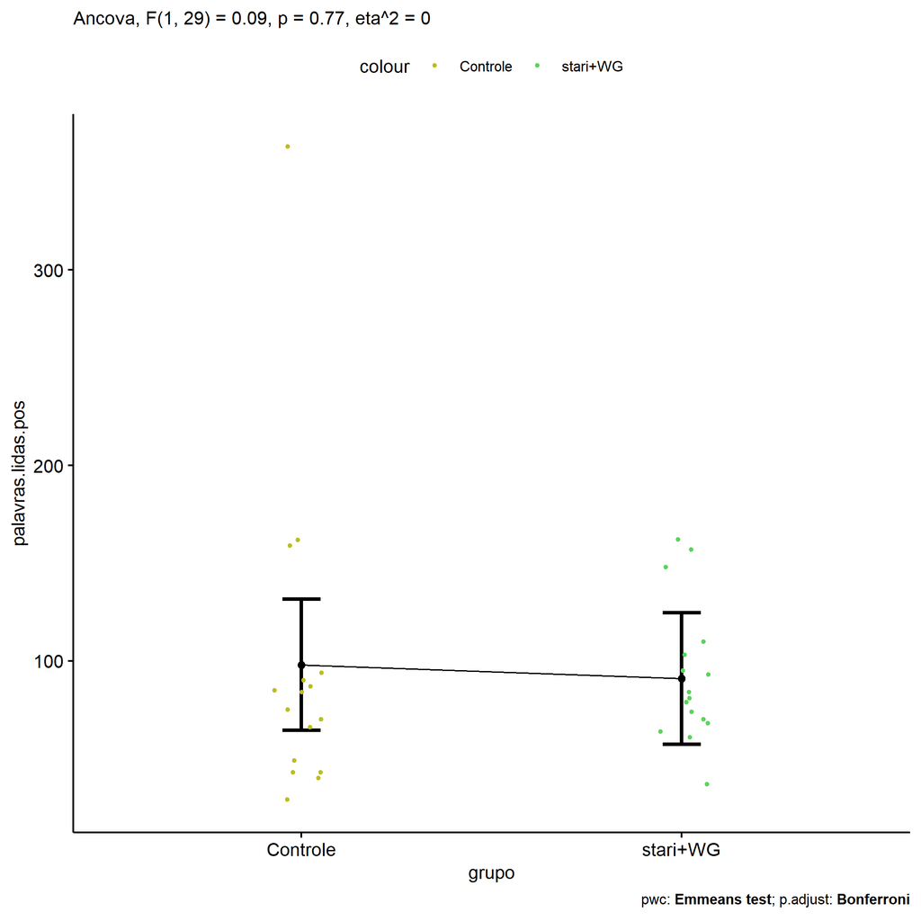

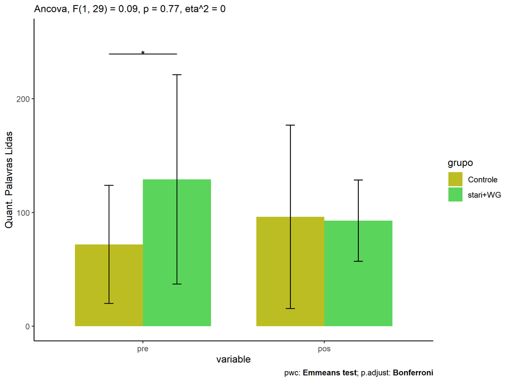

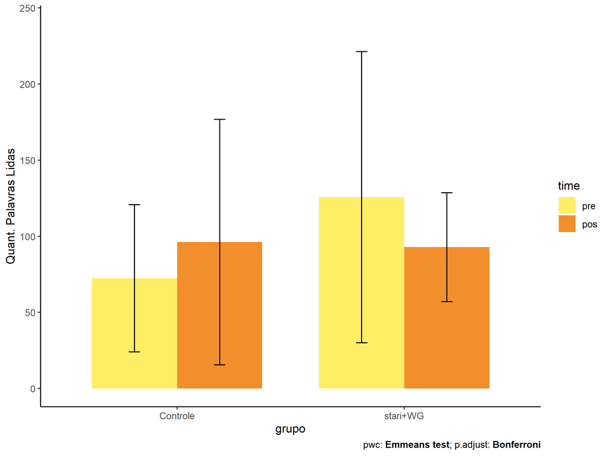

### Compreensao Leitora (Acertos)

| var | grupo | n | M (pre) | SE (pre) | M (unadj) | SE (unadj) | M (adj) | SE (adj) |
| --- | --- | --- | --- | --- | --- | --- | --- | --- |
| score.compreensao.pos | Controle | 18 | 3.222 | 0.298 | 3.167 | 0.513 | 3.411 | 0.441 |
| score.compreensao.pos | stari+WG | 16 | 4.125 | 0.598 | 4.188 | 0.510 | 3.912 | 0.469 |

| .y. | group1 | group2 | estimate | conf.low | conf.high | se | statistic | p | p.adj | p.adj.signif |
| --- | --- | --- | --- | --- | --- | --- | --- | --- | --- | --- |
| score.compreensao.pos | Controle | stari+WG | -0.501 | -1.833 | 0.831 | 0.653 | -0.767 | 0.449 | 0.449 | ns |
| score.compreensao.pre | Controle | stari+WG | -0.903 | -2.217 | 0.412 | 0.645 | -1.399 | 0.171 | 0.171 | ns |

| .y. | grupo | group1 | group2 | estimate | conf.low | conf.high | se | statistic | p | p.adj | p.adj.signif |
| --- | --- | --- | --- | --- | --- | --- | --- | --- | --- | --- | --- |
| score.compreensao | Controle | pre | pos | 0.307 | -1.046 | 1.660 | 0.679 | 0.452 | 0.652 | 0.652 | ns |
| score.compreensao | stari+WG | pre | pos | -0.473 | -1.839 | 0.892 | 0.685 | -0.691 | 0.492 | 0.492 | ns |

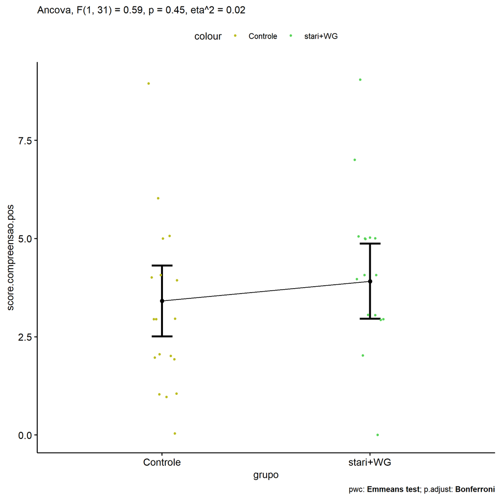

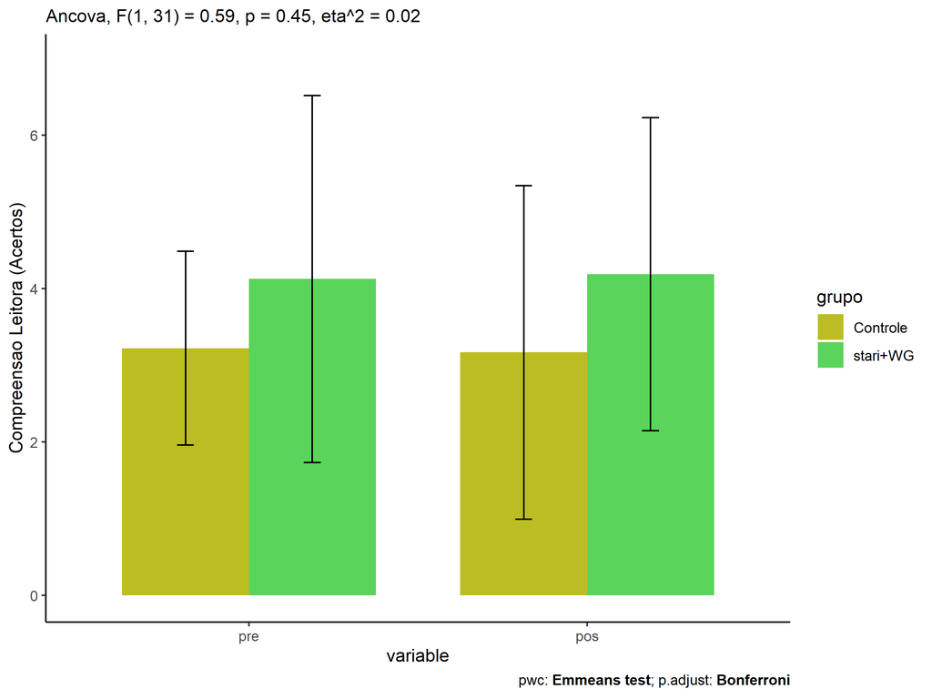

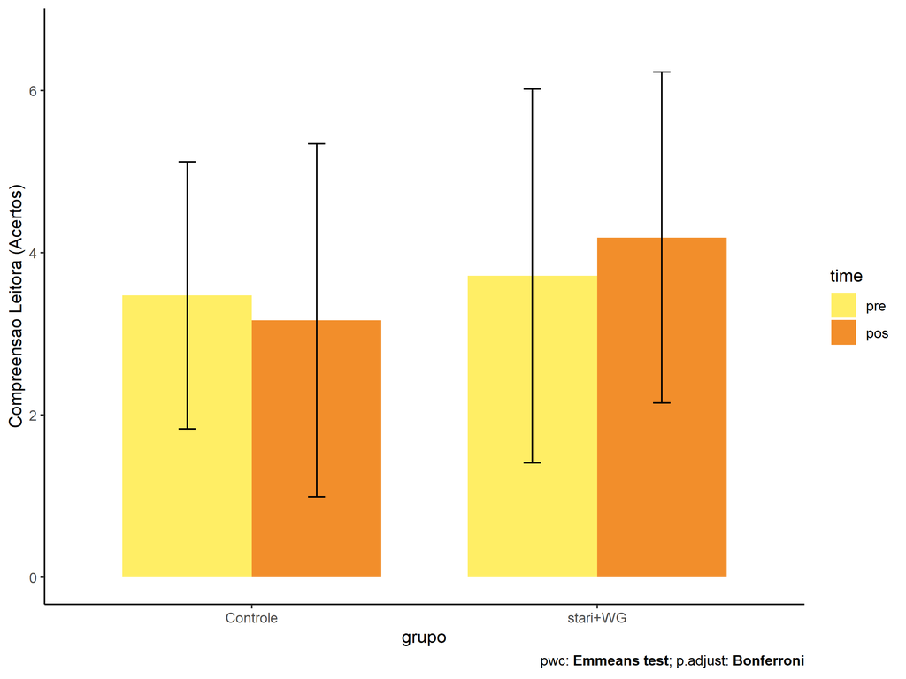

## factor: **genero**

### Quant. Palavras Lidas

| var | genero | n | M (pre) | SE (pre) | M (unadj) | SE (unadj) | M (adj) | SE (adj) |
| --- | --- | --- | --- | --- | --- | --- | --- | --- |
| palavras.lidas.pos | F | 9 | 60.222 | 11.842 | 87.889 | 11.417 | 89.265 | 21.953 |
| palavras.lidas.pos | M | 23 | 116.304 | 17.980 | 97.130 | 14.530 | 96.592 | 13.404 |

| .y. | group1 | group2 | estimate | conf.low | conf.high | se | statistic | p | p.adj | p.adj.signif |
| --- | --- | --- | --- | --- | --- | --- | --- | --- | --- | --- |
| palavras.lidas.pos | F | M | -7.327 | -61.085 | 46.431 | 26.285 | -0.279 | 0.782 | 0.782 | ns |
| palavras.lidas.pre | F | M | -56.082 | -117.177 | 5.013 | 29.915 | -1.875 | 0.071 | 0.071 | ns |

| .y. | genero | group1 | group2 | estimate | conf.low | conf.high | se | statistic | p | p.adj | p.adj.signif |
| --- | --- | --- | --- | --- | --- | --- | --- | --- | --- | --- | --- |
| palavras.lidas | F | pre | pos | -26.525 | -90.563 | 37.512 | 32.091 | -0.827 | 0.411 | 0.411 | ns |
| palavras.lidas | M | pre | pos | 18.042 | -21.739 | 57.823 | 19.936 | 0.905 | 0.369 | 0.369 | ns |

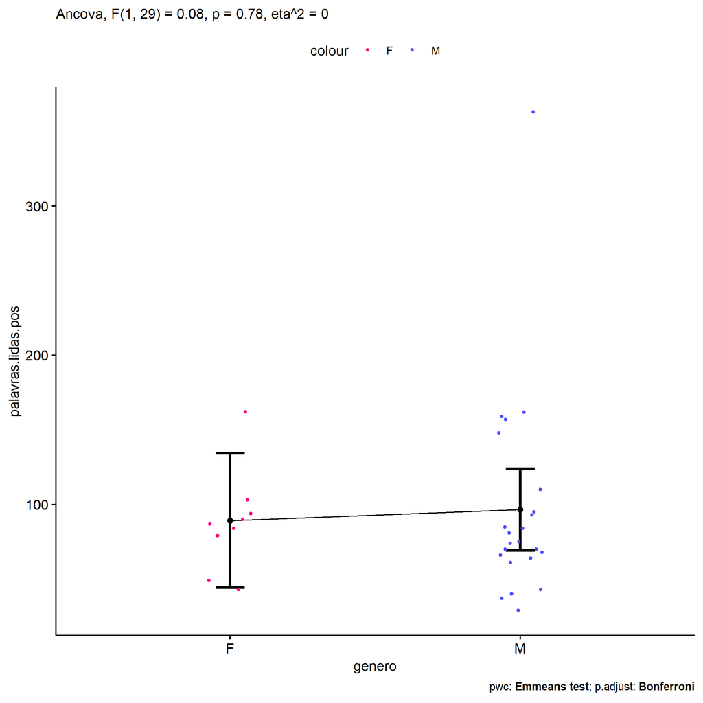

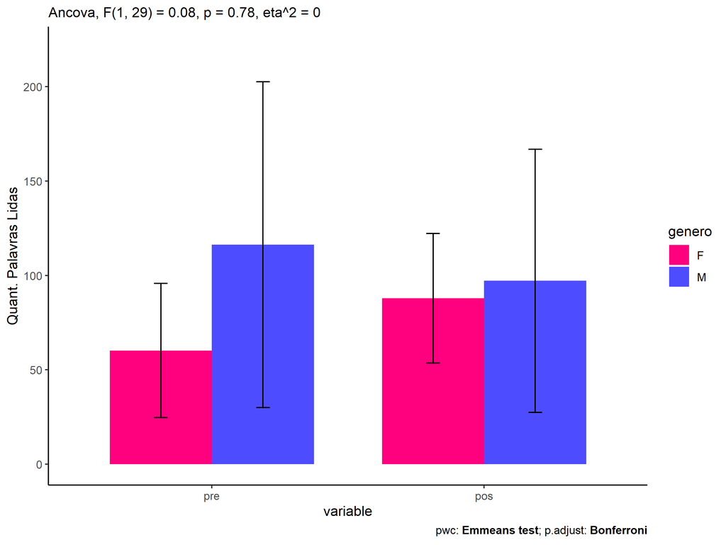

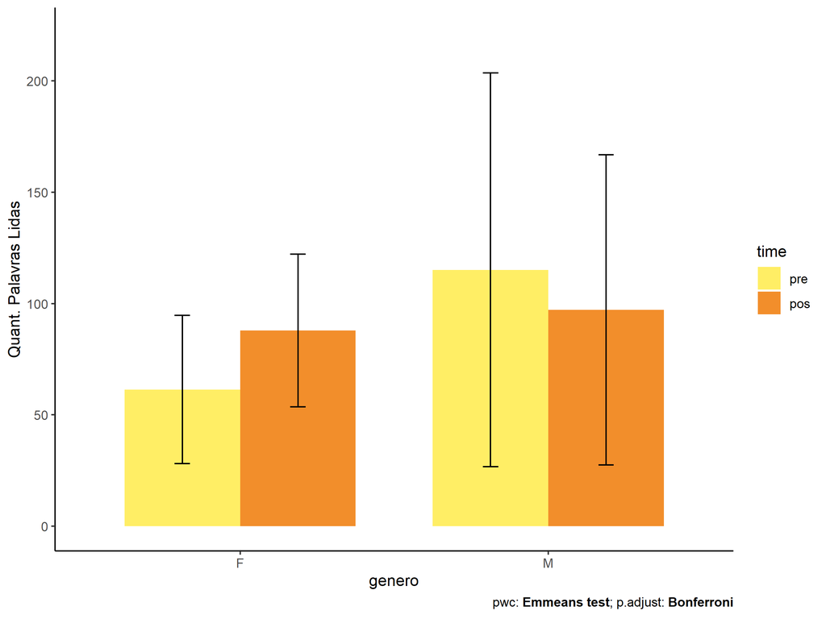

### Compreensao Leitora (Acertos)

| var | genero | n | M (pre) | SE (pre) | M (unadj) | SE (unadj) | M (adj) | SE (adj) |
| --- | --- | --- | --- | --- | --- | --- | --- | --- |
| score.compreensao.pos | F | 9 | 3.667 | 0.408 | 4.222 | 0.722 | 4.210 | 0.610 |
| score.compreensao.pos | M | 25 | 3.640 | 0.424 | 3.440 | 0.428 | 3.444 | 0.366 |

| .y. | group1 | group2 | estimate | conf.low | conf.high | se | statistic | p | p.adj | p.adj.signif |
| --- | --- | --- | --- | --- | --- | --- | --- | --- | --- | --- |
| score.compreensao.pos | F | M | 0.766 | -0.684 | 2.216 | 0.711 | 1.078 | 0.290 | 0.290 | ns |
| score.compreensao.pre | F | M | 0.027 | -1.505 | 1.558 | 0.752 | 0.035 | 0.972 | 0.972 | ns |

| .y. | genero | group1 | group2 | estimate | conf.low | conf.high | se | statistic | p | p.adj | p.adj.signif |
| --- | --- | --- | --- | --- | --- | --- | --- | --- | --- | --- | --- |
| score.compreensao | F | pre | pos | -0.677 | -2.543 | 1.189 | 0.936 | -0.723 | 0.472 | 0.472 | ns |
| score.compreensao | M | pre | pos | 0.181 | -0.952 | 1.314 | 0.568 | 0.318 | 0.751 | 0.751 | ns |

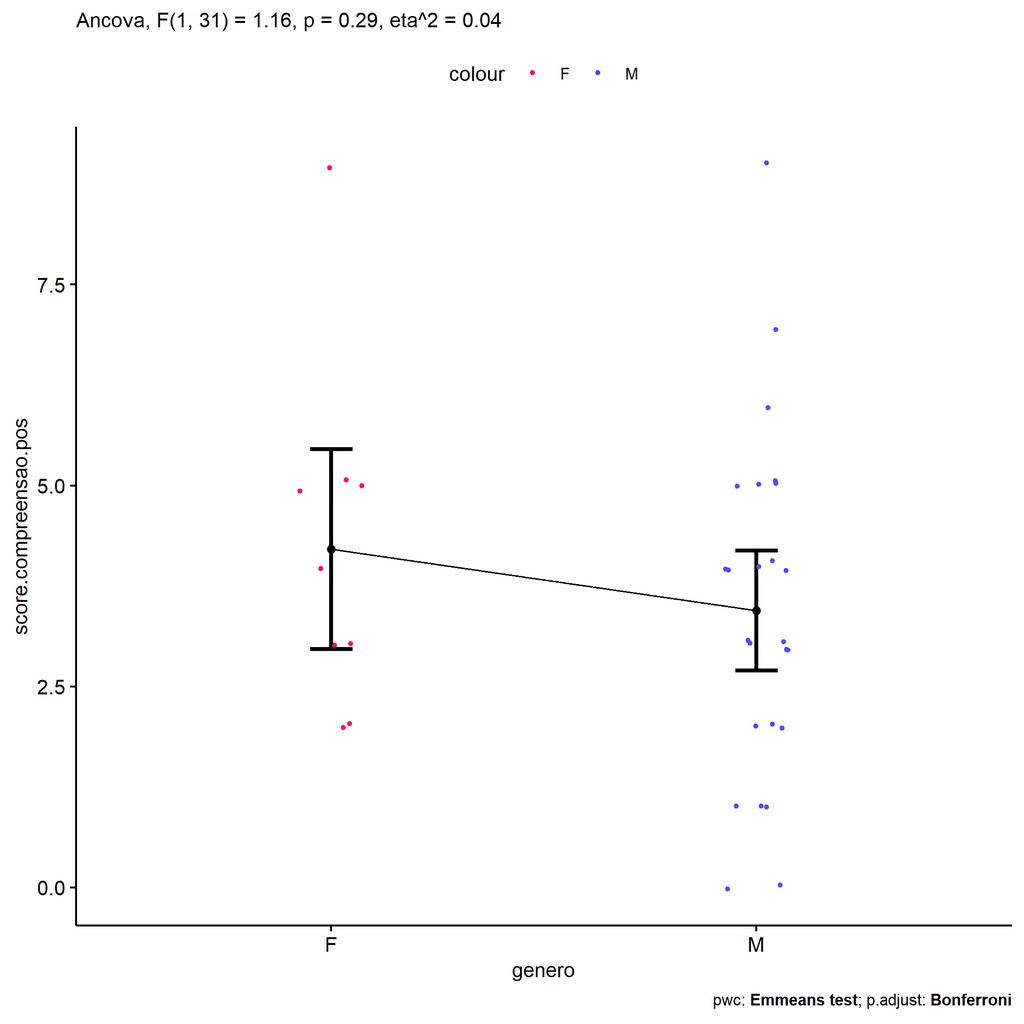

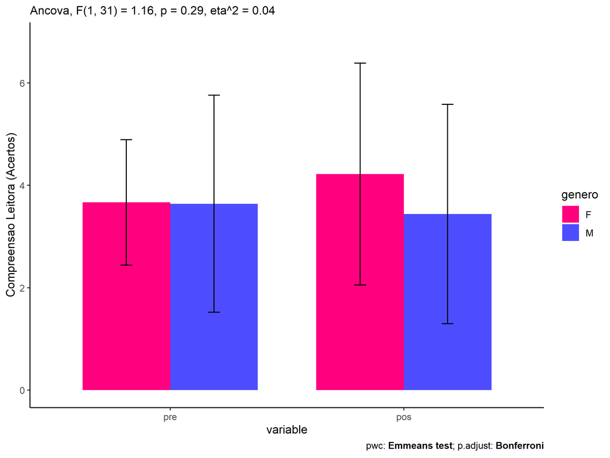

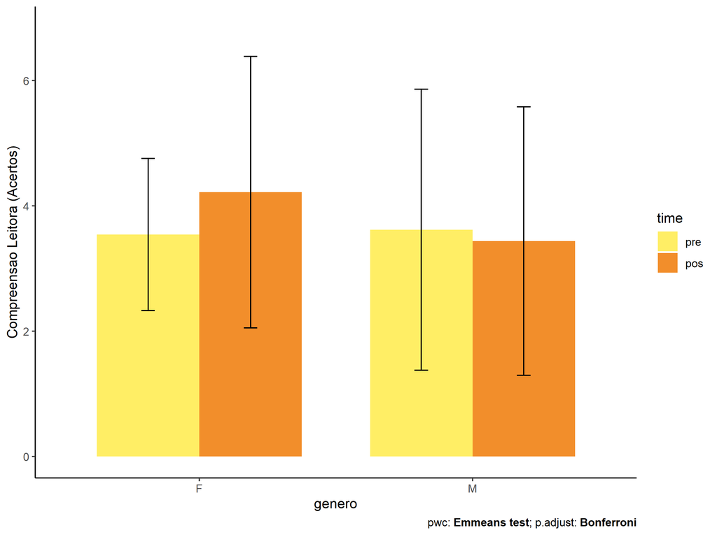